# 5 Preparación de los Datos

Es necesario realizar una preparación del conjunto de datos que considera correción de errores estructurales, filtrado de registros duplicados, gestión de valores atípicos, faltantes, validación y control de la calidad de los datos. Además, de la matriz de correlacion y las transformaciones de variables necesarias para los analisis posteriores.

## 5.1 Evaluación de la Calidad de los Datos

### 5.1.1 Identificación de Valores Duplicados

Eliminar registros duplicados garantiza que cada observación sea única y evita sesgos en el análisis. Los duplicados pueden distorsionar las estadísticas y afectar el desempeño del modelo al dar un peso desproporcionado a datos repetidos.

```
Registros duplicados encontrados:  0
```

No se identifican registros duplicados, lo que confirma la integridad inicial del conjunto de datos.

### 5.1.2 Manejo de Valores Faltantes

Se evalúa la cantidad y distribución de los valores faltantes en el conjunto de datos para identificar posibles problemas que puedan afectar los análisis.

| Variable | Valores Faltantes | Porcentaje (%) |
| --- | --- | --- |
| Horas_Estudio | 0 | 0.00 |
| Asistencia | 0 | 0.00 |
| Involucramiento_Parental | 0 | 0.00 |
| Acceso_Recursos | 0 | 0.00 |
| Actividades_Extracurriculares | 0 | 0.00 |
| Horas_Sueno | 0 | 0.00 |
| Puntuaciones_Previas | 0 | 0.00 |
| Nivel_Motivacion | 0 | 0.00 |
| Acceso_Internet | 0 | 0.00 |
| Sesiones_Tutoria | 0 | 0.00 |
| Ingresos_Familiares | 0 | 0.00 |
| Calidad_Profesor | 78 | 1.18 |
| Tipo_Escuela | 0 | 0.00 |
| Influencia_Companeros | 0 | 0.00 |
| Actividad_Fisica | 0 | 0.00 |
| Discapacidades_Aprendizaje | 0 | 0.00 |
| Nivel_Educativo_Padres | 90 | 1.36 |
| Distancia_Hogar | 67 | 1.01 |
| Sexo | 0 | 0.00 |
| Puntuacion_Examen | 0 | 0.00 |

Los resultados muestran valores faltantes mínimos, que no deberían afectar significativamente el análisis posterior:

- **Calidad del Profesor**: 78 valores faltantes (1.18%).
- **Nivel educativo de los padres**: 90 valores faltantes (1.36%).
- **Distancia del Hogar**: 67 valores faltantes (1.01%)

En lugar de imputar valores como la media, que podría introducir sesgo, se eliminan los registros faltantes de las variables clave para garantizar la calidad de los datos.

```
 Horas_Estudio     Asistencia     Involucramiento_Parental Acceso_Recursos
 Min.   : 1.00   Min.   : 60.00   Bajo :1291               Bajo :1274
 1st Qu.:16.00   1st Qu.: 70.00   Medio:3251               Medio:3204
 Median :20.00   Median : 80.00   Alto :1836               Alto :1900
 Mean   :19.98   Mean   : 80.02
 3rd Qu.:24.00   3rd Qu.: 90.00
 Max.   :44.00   Max.   :100.00
 Actividades_Extracurriculares  Horas_Sueno     Puntuaciones_Previas
 No:2571                       Min.   : 4.000   Min.   : 50.00
 Si:3807                       1st Qu.: 6.000   1st Qu.: 63.00
                               Median : 7.000   Median : 75.00
                               Mean   : 7.035   Mean   : 75.07
                               3rd Qu.: 8.000   3rd Qu.: 88.00
                               Max.   :10.000   Max.   :100.00
 Nivel_Motivacion Acceso_Internet Sesiones_Tutoria Ingresos_Familiares
 Baja :1864       No: 485         Min.   :0.000    Bajo :2582
 Media:3237       Si:5893         1st Qu.:1.000    Medio:2566
 Alta :1277                       Median :1.000    Alto :1230
                                  Mean   :1.495
                                  3rd Qu.:2.000
                                  Max.   :8.000
 Calidad_Profesor  Tipo_Escuela  Influencia_Companeros Actividad_Fisica
 Baja : 647       Publica:4434   Negativa:1330         Min.   :0.000
 Media:3826       Privada:1944   Neutral :2495         1st Qu.:2.000
 Alta :1905                      Positiva:2553         Median :3.000
                                                       Mean   :2.973
                                                       3rd Qu.:4.000
                                                       Max.   :6.000
 Discapacidades_Aprendizaje   Nivel_Educativo_Padres Distancia_Hogar
 No:5710                    Secundaria   :3159       Cerca   :3801
 Si: 668                    Universitaria:1939       Moderado:1941
                            Postgrado    :1280       Lejos   : 636



        Sexo      Puntuacion_Examen
 Femenino :2690   Min.   : 55.00
 Masculino:3688   1st Qu.: 65.00
                  Median : 67.00
                  Mean   : 67.25
                  3rd Qu.: 69.00
                  Max.   :101.00
```

### 5.1.3 Manejo de Valores Atípicos

Los valores atípicos pueden distorsionar estadísticas descriptivas, como la media, y afectar modelos predictivos al dar peso desproporcionado a registros extremos. Para identificarlos, se utilizó el **rango intercuartílico (IQR)** y se analizó su impacto en la distribución.

#### 5.1.3.1 Detección de Valores Atípicos

Primero se identificaron los valores atípicos mediante el cálculo del IQR. A continuación, se presenta la cantidad y el porcentaje de valores atípicos por variable:

| Variable | Atípicos | (%) |
| --- | --- | --- |
| Horas de Estudio | 40 | 0.63 |
| Asistencia | 0 | 0.00 |
| Horas de Sueño | 0 | 0.00 |
| Puntuaciones Previas | 0 | 0.00 |
| Sesiones de Tutoría | 423 | 6.63 |
| Actividad Física | 0 | 0.00 |
| Puntuación de Examen | 103 | 1.61 |

Al recalcular los valores atípicos tras la eliminación de registros con valores faltantes, se observó una reducción en el número de estos, aunque se identificaron en las mismas variables que en el análisis exploratorio inicial. Este ajuste refleja el impacto de trabajar con un dataset depurado, lo que modifica ligeramente los cálculos estadísticos, como el rango intercuartílico (IQR).

Específicamente, los valores atípicos disminuyeron de la siguiente manera:

- En **Horas de Estudio**, se redujeron de 43 a 40 observaciones, representando el 0.63% del total.
- En **Sesiones de Tutoría**, disminuyeron de 430 a 423 observaciones, lo que equivale al 6.63% del total.
- En **Puntuación de Examen**, pasaron de 104 a 103 observaciones, representando el 1.61% del total.

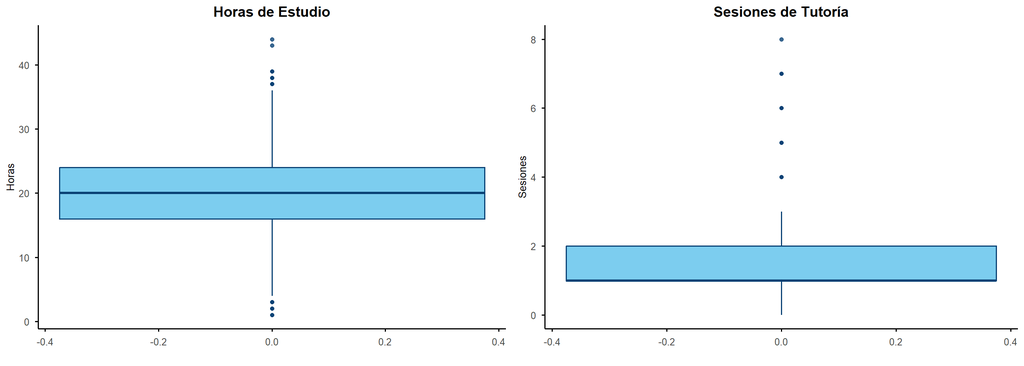

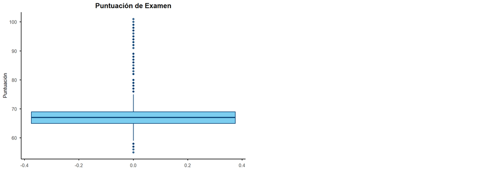

En las variables **Horas de Estudio** y **Puntuación de Examen** no se intervendra en los valores atípicos, ya que aparentemente representan comportamientos extremos válidos. Se usara la mediana o el valor transformado si afecta mucho la media.

En relación a las **Sesiones de Tutoría**, dado el 6.63% de valores atípicos y estan en la parte alta, donde se mejora la mediana, se intentara explicar su naturaleza y hacer transformaciones de esta variable para intentar reducir el efecto de los extremos.

#### 5.1.3.2 Interpretación de los Valores Atípicos

Al analizar las Sesiones de Tutoría, observamos que los valores atípicos en la cola derecha pueden reflejar un fenómeno importante:

#### 5.1.3.3 Conclusión

Los valores atípicos identificados en las variables Horas de Estudio, Sesiones de Tutoría y Puntuación de Examen reflejan comportamientos extremos que, en algunos casos, tienen sentido práctico dentro del contexto educativo. Por ejemplo, los valores altos en Sesiones de Tutoría están asociados con mejores puntuaciones en los exámenes, lo que podría deberse a intervenciones educativas específicas o un mayor esfuerzo académico.

No se aplicará ninguna transformación en esta etapa. Los valores atípicos serán evaluados nuevamente en el apartado Transformación de Variables, donde se analizará si es necesario aplicar ajustes, para corregir asimetrías o reducir el impacto de valores extremos en los modelos.

En etapas posteriores del análisis, se determinará si las variables originales o transformadas mejoran el desempeño de los modelos predictivos.

## 5.2 Matriz de Correlación

La matriz de correlación se utiliza para analizar la relación lineal entre las variables numéricas del conjunto de datos. Este paso es importante porque permite identificar qué variables tienen una mayor asociación con la Puntuación de Examen, que es la variable dependiente, y también ayuda a detectar posibles problemas de colinealidad entre las variables explicativas.

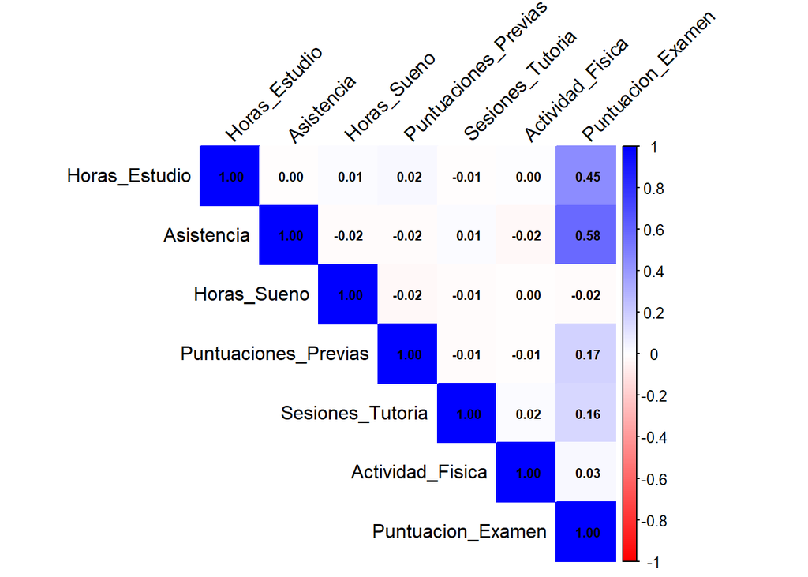

La matriz de correlación presentada muestra las relaciones lineales entre las variables numéricas del conjunto de datos. Su interpretación se detalla a continuación.

### 5.2.1 Evaluación de Colinealidad

Aunque la matriz de correlación permite identificar relaciones entre variables, también es importante analizar la colinealidad entre las variables explicativas. La colinealidad ocurre cuando dos o más variables independientes están altamente correlacionadas, lo que puede generar:

- Inestabilidad en los coeficientes del modelo.
- Problemas de interpretación de los resultados.

Para evaluar la colinealidad, se utiliza el Factor de Inflación de Varianza (VIF):

Factor de Inflación de Varianza (VIF)

|  | Variable | VIF |
| --- | --- | --- |
| Horas_Estudio | Horas_Estudio | 1 |
| Asistencia | Asistencia | 1 |
| Horas_Sueno | Horas_Sueno | 1 |
| Puntuaciones_Previas | Puntuaciones_Previas | 1 |
| Sesiones_Tutoria | Sesiones_Tutoria | 1 |
| Actividad_Fisica | Actividad_Fisica | 1 |

#### 5.2.1.1 Interpretación de los Resultados del VIF

**Regla general**:

- Un VIF menor a 5 indica que no existe colinealidad significativa.  
- Un VIF entre 5 y 10 sugiere colinealidad moderada.  
- Un VIF mayor a 10 indica colinealidad alta y requiere intervención.

**Resultados observados**:

Todos los valores de VIF son menores a 5, lo que sugiere que **no existe colinealidad significativa** entre las variables seleccionadas. Por lo tanto, estas variables pueden ser incluidas en el modelo sin necesidad de ajustes adicionales.

#### 5.2.1.2 Conclusión

La matriz de correlación muestra las relaciones lineales entre las variables numéricas y la Puntuación de Examen. Se observan correlaciones importantes, como Asistencia (0.58) y Horas de Estudio (0.45), mientras que otras variables presentan una relación débil o nula.

La evaluación del VIF confirma que no existe colinealidad significativa entre las variables explicativas, lo que sugiere que no será necesario realizar ajustes adicionales en este aspecto por ahora. Sin embargo, se continuará evaluando las variables numéricas en etapas posteriores del análisis, especialmente al validar los resultados del modelo.

## 5.3 Transformación de Variables

La transformación de variables se realiza para corregir problemas de distribución, reducir el efecto de valores extremos y mejorar la relación lineal entre las variables en un análisis predictivo. Este paso es especialmente útil para garantizar que las variables numéricas estén adecuadamente preparadas para modelos sensibles a la escala, como la regresión lineal.

En este apartado, se aplicaron diferentes técnicas de transformación a variables seleccionadas para evaluar su impacto en la distribución y su relación con la variable dependiente, Puntuación de Examen. Además, se consideró la normalización de variables numéricas como un paso clave para asegurar la coherencia en el modelo.

### 5.3.1 Transformación de Sesiones de Tutoría

La variable **Sesiones de Tutoría** presenta una distribución asimétrica hacia la derecha (asimetría positiva), lo que sugiere la necesidad de una transformación logarítmica para reducir el impacto de los valores atípicos.

```
   Min. 1st Qu.  Median    Mean 3rd Qu.    Max.
 0.0000  0.6931  0.6931  0.7877  1.0986  2.1972
```

#### 5.3.1.1 Gráficos Comparativos

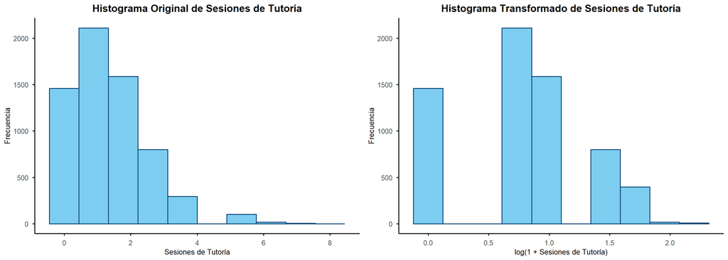

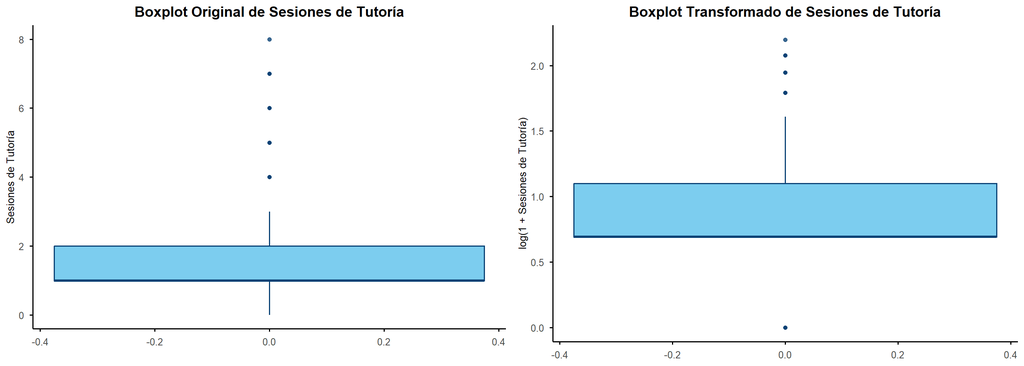

#### 5.3.1.2 Análisis de la Transformación

La transformación logarítmica aplicada a la variable Sesiones de Tutoría logra reducir la asimetría positiva de su distribución, compactando la cola derecha y disminuyendo el impacto de los valores extremos. Sin embargo, también introduce una concentración de valores bajos y nuevos valores atípicos en esta zona, lo que podría influir en la interpretación del modelo.

Al considerar el contexto educativo, los valores atípicos en la parte alta representan un fenómeno relevante (mayor número de sesiones de tutoría asociado a un mejor rendimiento), por lo que la decisión de transformar o no esta variable dependerá del impacto en el modelo final.

### 5.3.2 Transformación de Asistencia

La variable **Asistencia** muestra una distribución no normal. Para evaluar su posible mejora, se aplicaron tres transformaciones: logarítmica, raíz cuadrada y Box-Cox.

#### 5.3.2.1 Gráficos Comparativos

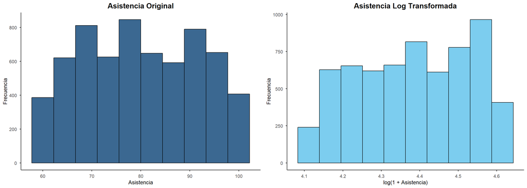

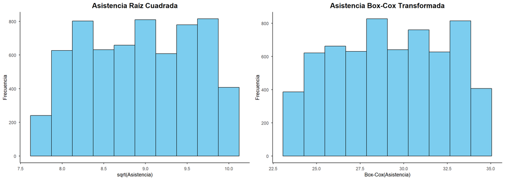

En los histogramas se observa que la Asistencia Original tiene una distribución uniforme entre 60% y 100% y se compara con las transformaciones:

- Transformación Logarítmica: compacta los valores bajos y suaviza ligeramente la cola alta. Sin embargo, no corrige por completo la distribución.
- Transformación Raíz Cuadrada: es la más equilibrada, ya que reduce de manera uniforme los valores extremos bajos y altos sin distorsionar la estructura central de los datos.
- Transformación Box-Cox: ajusta principalmente los valores altos.

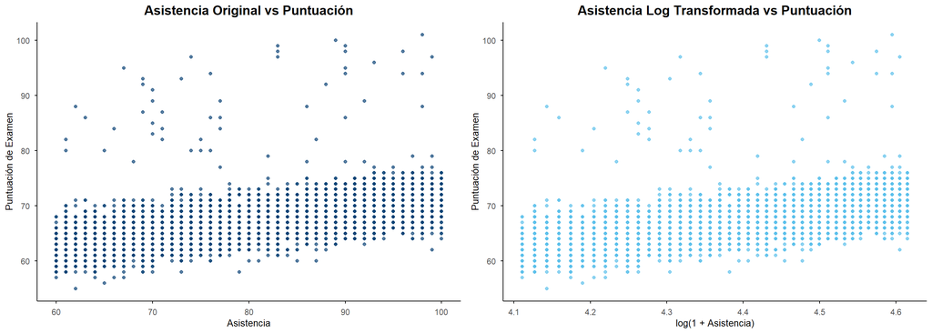

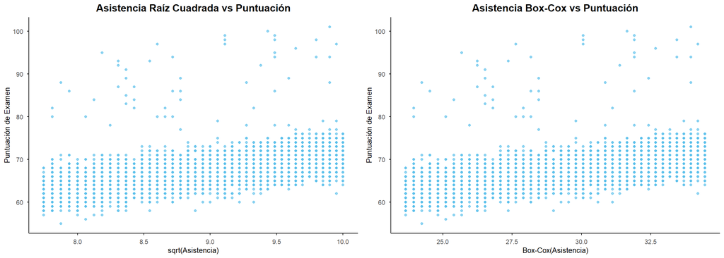

El gráfico de dispersión combinado revela que las transformaciones no modifican significativamente la relación entre Asistencia y Puntuación de Examen. La tendencia positiva observada en la variable original se mantiene en todas las versiones transformadas.

Dado que la Asistencia Original ya presenta una relación positiva moderada con la Puntuación de Examen, podría utilizarse directamente en el modelo. No obstante, si al analizar los residuos del modelo de regresión se detectan problemas de normalidad o linealidad, la transformación raíz cuadrada sería la primera opción a considerar, aunque se evaluarán también las otras transformaciones para seleccionar la más adecuada.

## 5.4 Codificación de Variables Categóricas

La codificación de variables categóricas es un paso esencial en modelos predictivos, como la regresión lineal, que requieren que todas las variables sean numéricas. En este caso, se utiliza One-Hot Encoding, una técnica que convierte cada categoría de una variable en una nueva columna binaria. Estas columnas toman el valor 1 si el registro pertenece a esa categoría y 0 en caso contrario.

Las variables seleccionadas para la codificación se han organizado según los factores internos, externos y dependientes de la escuela:

- **Factores Internos:**
  - Nivel de Motivación
- **Factores Externos:**
  - Involucramiento Parental.
- **Factores Dependientes:**
  - Tipo de Escuela
  - Calidad del Profesor

### 5.4.1 Aplicación de One-Hot Encoding

Para realizar la codificación, se eliminó una columna de referencia en cada variable para evitar problemas de multicolinealidad. La multicolinealidad ocurre cuando las variables predictoras están altamente correlacionadas entre sí, lo que puede distorsionar los coeficientes en un modelo de regresión lineal y dificultar la interpretación de los efectos de cada variable.

Por ejemplo, si la variable `Calidad_Profesor` tiene las categorías **Alta**, **Media** y **Baja**, solo se incluiran dos nuevas columnas (`Calidad_Profesor_Alta`y `Calidad_Profesor_Media`), mientras que la categoría **Baja** se tomará como referencia implícita.

## 5.5 Verificación de las Nuevas Variables

Se realizó una verificación de las columnas generadas para confirmar que la codificación se realizó correctamente. Esto incluye:

- Los nombres de las nuevas columnas generadas por One-Hot Encoding.
- Los valores binarios (0 o 1) que se asignaron correctamente a las categorías correspondientes.

```
  Horas_Estudio Asistencia Acceso_Recursos Actividades_Extracurriculares
1            23         84            Alto                            No
2            19         64           Medio                            No
3            24         98           Medio                            Si
4            29         89           Medio                            Si
5            19         92           Medio                            Si
6            19         88           Medio                            Si
  Horas_Sueno Puntuaciones_Previas Acceso_Internet Sesiones_Tutoria
1           7                   73              Si                0
2           8                   59              Si                2
3           7                   91              Si                2
4           8                   98              Si                1
5           6                   65              Si                3
6           8                   89              Si                3
  Ingresos_Familiares Influencia_Companeros Actividad_Fisica
```

[output cut: 41 more lines]

Los nombres de las columnas confirmaron que las nuevas variables fueron creadas con prefijos que indican su variable original. Por ejemplo, `Calidad_Profesor` generó la columna `Calidad_Profesor_Alta` y `Calidad_Profesor_Media`. Esta estructura permite que las variables categóricas se integren de manera efectiva en el modelo de regresión.

```
 [1] "Horas_Estudio"                  "Asistencia"
 [3] "Acceso_Recursos"                "Actividades_Extracurriculares"
 [5] "Horas_Sueno"                    "Puntuaciones_Previas"
 [7] "Acceso_Internet"                "Sesiones_Tutoria"
 [9] "Ingresos_Familiares"            "Influencia_Companeros"
[11] "Actividad_Fisica"               "Discapacidades_Aprendizaje"
[13] "Nivel_Educativo_Padres"         "Distancia_Hogar"
[15] "Sexo"                           "Puntuacion_Examen"
[17] "Sesiones_Tutoria_log"           "Asistencia_log"
[19] "Asistencia_sqrt"                "Asistencia_boxcox"
[21] "Nivel_Motivacion_Media"         "Nivel_Motivacion_Alta"
[23] "Involucramiento_Parental_Medio" "Involucramiento_Parental_Alto"
[25] "Calidad_Profesor_Media"         "Calidad_Profesor_Alta"
[27] "Tipo_Escuela_Privada"
```